# Ejemplo Anova

Julio Zainea

20 de marzo de 2020

## Ejemplo

Para nuestro ejemplo usaremos una base de datos que tiene información sociodemográfica de 173 países del mundo, tendremos en cuenta las variables “continent” y “employrate”, nuestro interés será verificar si hay diferencias en las tasas de empleo medio categorizando los continentes.

Primero cargaremos las librerías necesarias y cargaremos la base de datos

```r
data.world <- read.csv2("https://raw.githubusercontent.com/shhschilling/statistikUmweltingenieure/master/data/gapC.csv",sep=",",dec=".")
data.world=data.world[complete.cases(data.world$employrate),]
data.world=data.frame(data.world)
attach(data.world)
names(data.world)
```

```
##  [1] "country"            "incomeperperson"    "alcconsumption"
##  [4] "armedforcesrate"    "breastcancer"       "co2emissions"
##  [7] "femaleemployrate"   "hivrate"            "internetuserate"
## [10] "lifeexpectancy"     "oilperperson"       "polityscore"
## [13] "relectricperperson" "suicideper100th"    "employrate"
## [16] "urbanrate"          "continent"
```

Nuestro problema es tomar la decisión frente a la siguiente prueba de hipótesis
$$H_0: \mu_{AF}=\mu_{EE}=\mu_{WE}=\mu_{OC}=\mu_{AS}=\mu_{LATAM}=\mu_{NORAM}\\
H_a: al menos una es diferente a las demás$$
Inicialmente veremos el comportamiento de manera descriptiva.

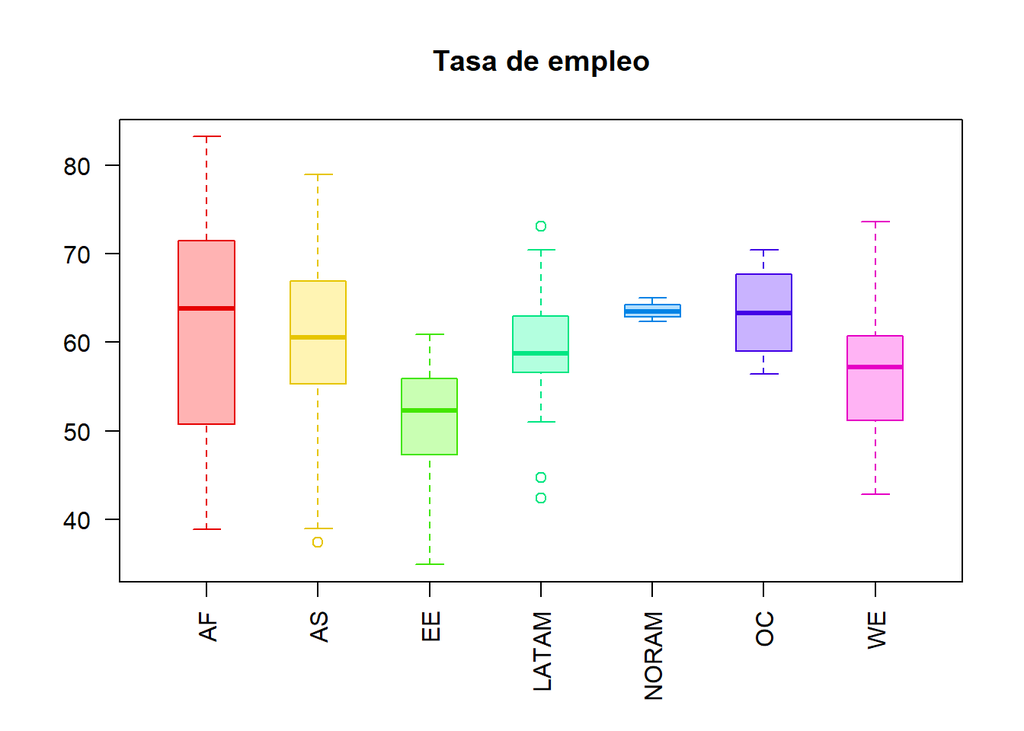

```r
boxplot(employrate~continent,data=data.world,
        col=rainbow(7,alpha=0.3),
        border=rainbow(7,v=0.9),boxwex=0.5,
        xlab="",ylab="",
        main="Tasa de empleo",las=2)
```

```r
aggregate(data.world$employrate,by=list(data.world$continent),mean)
```

```
##   Group.1        x
## 1      AF 61.59636
## 2      AS 60.89714
## 3      EE 50.69545
## 4   LATAM 59.24643
## 5   NORAM 63.60000
## 6      OC 63.32500
## 7      WE 56.33809
```

Ahora haremos el anova

```r
anova=aov(employrate~continent,data=data.world )
summary(anova)
```

```
##              Df Sum Sq Mean Sq F value  Pr(>F)
## continent     6   2302   383.7   3.938 0.00106 **
## Residuals   161  15689    97.4
## ---
## Signif. codes:  0 '***' 0.001 '**' 0.01 '*' 0.05 '.' 0.1 ' ' 1
```

$$H_0: \texttt{Los datos son normales}\\
H_a: \texttt{Los datos no son normales}$$

```r
errores=residuals(anova)
shapiro.test(errores)
```

```
##
##  Shapiro-Wilk normality test
##
## data:  errores
## W = 0.98702, p-value = 0.1225
```

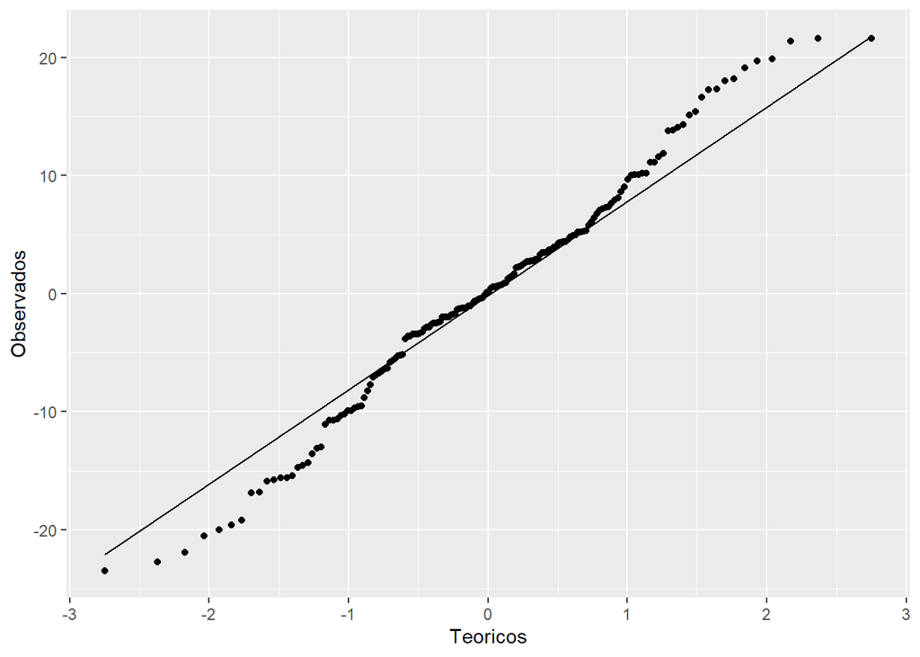

```r
df <- data.frame(y =errores)
p <- ggplot(df, aes( sample=y))
p + stat_qq() + stat_qq_line()+xlab("Teoricos")+ylab("Observados")
```

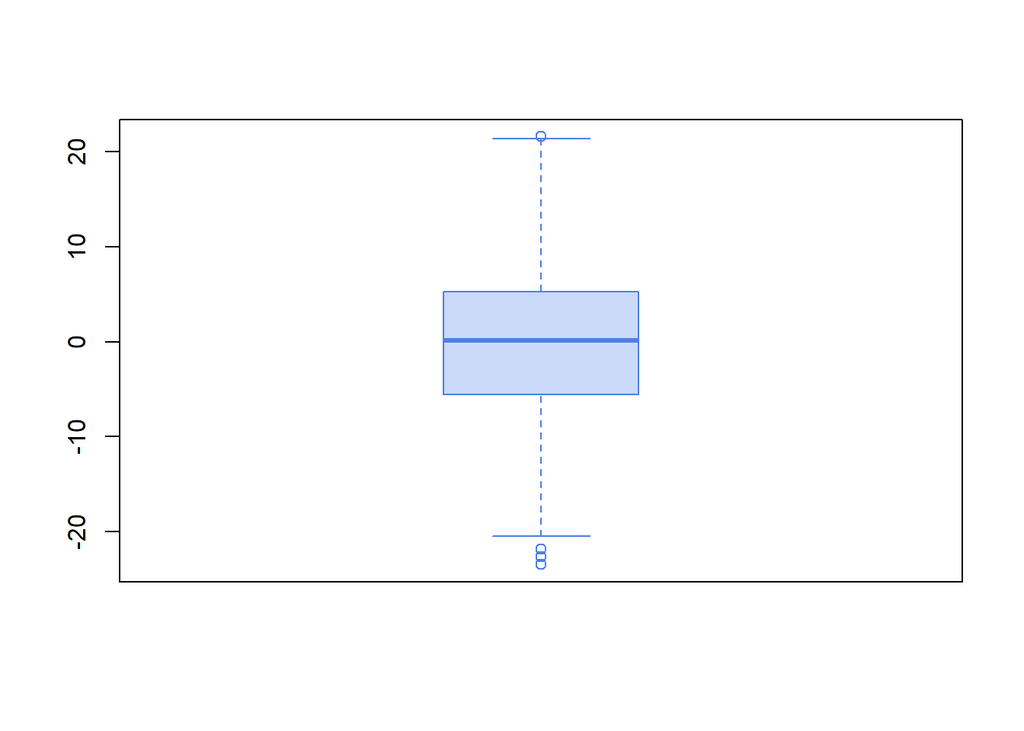

```r
caja=boxplot(errores,col=rgb(0.3,0.5,0.9,0.3),boxwex=0.5,border=rgb(0.3,0.5,0.9,1))
```

## Homocedasticidad

$$H_0: \texttt{Los datos son Homocedasticos} \\
H_a: \texttt{Los datos son Heterocedasticos}$$

```r
#bptest(errores~continent)
bartlett.test(errores ~continent)
```

```
##
##  Bartlett test of homogeneity of variances
##
## data:  errores by continent
## Bartlett's K-squared = 29.098, df = 6, p-value = 5.829e-05
```

```r
leveneTest(errores~ continent)
```

```
## Levene's Test for Homogeneity of Variance (center = median)
##        Df F value    Pr(>F)
## group   6  5.2665 5.567e-05 ***
##       161
## ---
## Signif. codes:  0 '***' 0.001 '**' 0.01 '*' 0.05 '.' 0.1 ' ' 1
```

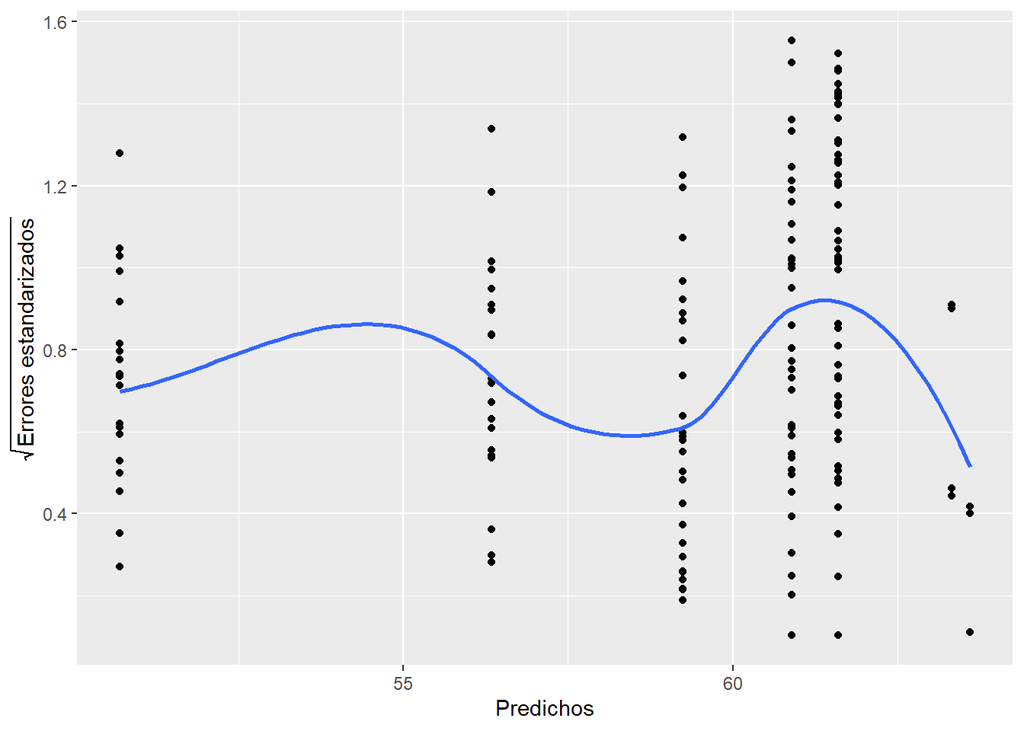

```r
ee=sqrt(abs(rstandard(anova)))
yest=predict(anova)
df=data.frame(ee,yest)

ggplot(df,aes(x=yest,y=ee))+geom_point()+xlab(expression("Predichos"))+ylab(expression(sqrt("Errores estandarizados")))+
  geom_smooth(se=F,method = 'loess')
```

## Independencia

$$H_0: \texttt{Los errores son independientes}\\
H_a: \texttt{Los errores son dependientes}$$

```r
dwtest(anova)
```

```
##
##  Durbin-Watson test
##
## data:  anova
## DW = 1.7939, p-value = 0.09022
## alternative hypothesis: true autocorrelation is greater than 0
```

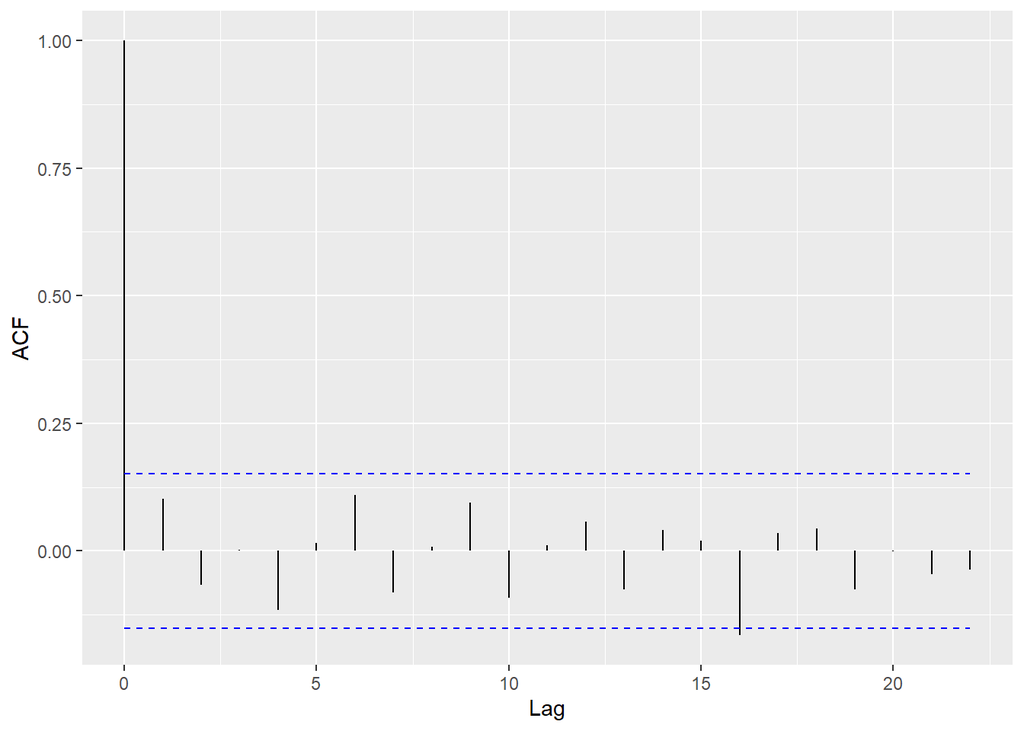

```r
autoplot(acf(anova$residuals, plot = FALSE))
```

## Comparaciones múltiples

Ahora nuestro interés será determinar y caracterizar el comportamiento de las tasas de empleo por continente, es decir saber cual es el orden de los continentes teniendo en cuenta a esa variable. Para esto usaremos los test de comparaciones múltiples

```r
LSD.compa=LSD.test(anova,"continent",alpha = 0.05)
print(LSD.compa)
```

```
## $statistics
##    MSerror  Df     Mean       CV
##   97.44959 161 59.05119 16.71712
##
## $parameters
##         test p.ajusted    name.t ntr alpha
##   Fisher-LSD      none continent   7  0.05
##
## $means
##       employrate       std  r      LCL      UCL  Min  Max    Q25   Q50
## AF      61.59636 12.836882 55 58.96771 64.22502 38.9 83.2 50.700 63.80
## AS      60.89714 10.107757 35 57.60195 64.19234 37.4 78.9 55.250 60.50
## EE      50.69545  6.520625 22 46.53919 54.85172 34.9 60.9 47.300 52.25
## LATAM   59.24643  6.731049 28 55.56229 62.93057 42.4 73.1 56.675 58.70
## NORAM   63.60000  1.352775  3 52.34477 74.85523 62.3 65.0 62.900 63.50
## OC      63.32500  5.892014  4 53.57769 73.07231 56.4 70.4 60.225 63.25
## WE      56.33809  7.393611 21 52.08402 60.59217 42.8 73.6 51.200 57.20
##          Q75
## AF    71.450
## AS    66.900
## EE    55.825
## LATAM 62.825
## NORAM 64.250
## OC    66.350
## WE    60.700
##
## $comparison
## NULL
##
## $groups
##       employrate groups
## NORAM   63.60000      a
## OC      63.32500      a
## AF      61.59636      a
## AS      60.89714      a
## LATAM   59.24643      a
## WE      56.33809     ab
## EE      50.69545      b
##
## attr(,"class")
## [1] "group"
```

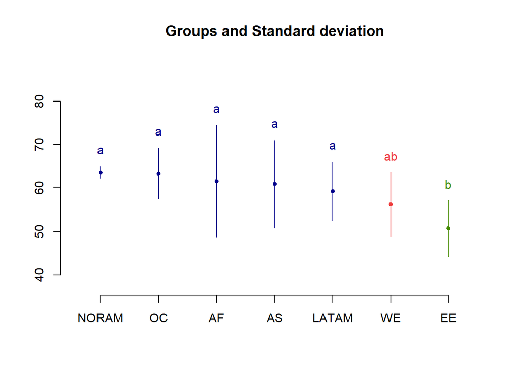

```r
plot(LSD.compa,variation = "SD")
```

```r
HSD.compa=HSD.test(anova,"continent",alpha = 0.05)
print(HSD.compa)
```

```
## $statistics
##    MSerror  Df     Mean       CV
##   97.44959 161 59.05119 16.71712
##
## $parameters
##    test    name.t ntr StudentizedRange alpha
##   Tukey continent   7         4.222816  0.05
##
## $means
##       employrate       std  r  Min  Max    Q25   Q50    Q75
## AF      61.59636 12.836882 55 38.9 83.2 50.700 63.80 71.450
## AS      60.89714 10.107757 35 37.4 78.9 55.250 60.50 66.900
## EE      50.69545  6.520625 22 34.9 60.9 47.300 52.25 55.825
## LATAM   59.24643  6.731049 28 42.4 73.1 56.675 58.70 62.825
## NORAM   63.60000  1.352775  3 62.3 65.0 62.900 63.50 64.250
## OC      63.32500  5.892014  4 56.4 70.4 60.225 63.25 66.350
## WE      56.33809  7.393611 21 42.8 73.6 51.200 57.20 60.700
##
## $comparison
## NULL
##
## $groups
##       employrate groups
## NORAM   63.60000      a
## OC      63.32500      a
## AF      61.59636      a
## AS      60.89714      a
## LATAM   59.24643      a
## WE      56.33809     ab
## EE      50.69545     ab
##
## attr(,"class")
## [1] "group"
```

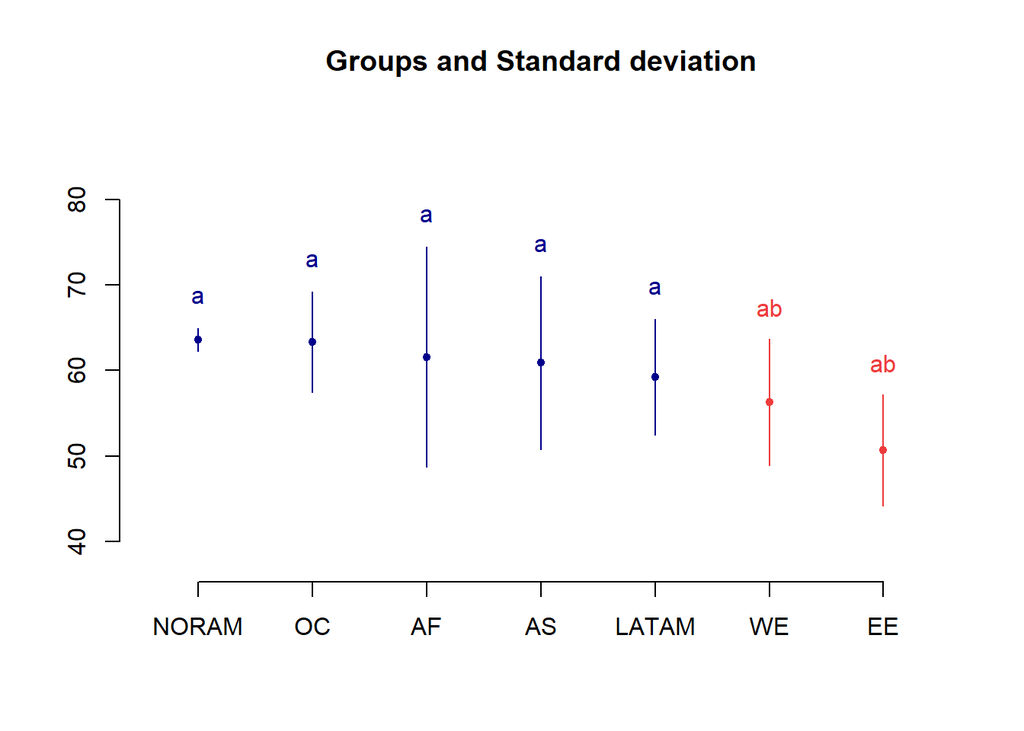

```r
plot(HSD.compa,variation = "SD")
```

## Ejercicio

1. Investigar y realizar las comparaciones múltiples usando el método de Dunnett y el de Bonferroni para nuestro ejemplo.
2. Investigar las diferencias entre los métodos de comaraciones múltiples